# APP: UI/UX: Пользовательские интерфейсы и сценарии AgroTracker

Published

June 11, 2026

**WarningОграничение публичной документации**

В открытом доступе представлена **демонстрационная версия** метода. В настоящей публичной документации отображены не все шаги, технические сценарии и приватные эндпоинты для системы цифровых симуляторов бизнес-процессов.

- **Полная спецификация метода:** Будет доступна только во внутреннем контуре разработки (Confluence / Swagger Enterprise).

Настоящий документ регламентирует структуру интерфейсов, состав визуальных элементов и продуктовые User Journeys (пользовательские сценарии) мобильного терминала Flutter для учета выработки наемных рабочих.

## 1 Экран «Авторизация и Регистрация» (Вход оператора)

Экран отвечает за первичный фидуциарный скоринг и идентификацию наемного рабочего в системе перед предоставлением доступа к каскаду справочников.

### 1.1 Визуальные элементы и элементы управления (UI Elements)

- **Поля ввода текстовой информации:** Текстовые инпуты «Corporate Identity Email» и «Secure Access Password» с встроенной маской валидации регулярных выражений.
- **Главная управляющая кнопка:** Кнопка «AUTHORIZE ENTRANCE». Инициализирует бинарный gRPC-вызов `LoginRequest` на бэкенд (порт :8080).
- **Альтернативная кнопка переключения стейта:** Текстовая кнопка «Нет аккаунта? Зарегистрироваться» в `bottomNavigationBar` для мгновенного перехода в контур регистрации без смены экрана.

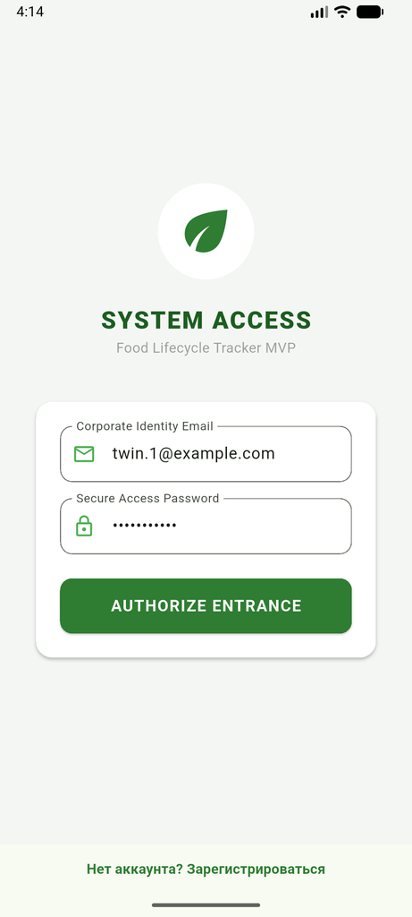

Figure 1: Интерфейс экрана авторизации

### 1.2 Продуктовые сценарии поведения (Happy Path / Edge Cases)

1. **Сценарий «Успешный вход оператора» (Happy Path):** Рабочий вводит легитимный email. Система за 24 мс выполняет gRPC-запрос, параллельно проверяя статус в Государственной SOAP-платформе. При ответе `SUCCESS` генерируется JWT-пара, и приложение переключает стейт контроллера `_currentStep` на шаг `COMPANY`.
2. **Сценарий «Блокировка внешней госсистемой» (Edge Case - Сценарий twin.2):** При попытке входа под заблокированным в Гос-СУБД email, бэкенд Go возвращает gRPC Error (Код 16). Интерфейс Flutter перехватывает эксепшен и выводит жесткий блокирующий красный SnackBar: *«account is blocked by governmental decree»*.
3. **Сценарий «Регистрация нового сотрудника»:** Переиспользует форму ввода. При клике на регистрацию отправляет запрос `RegisterRequest`. При успешном ответе SOAP (`SUCCESS`) создает запись в локальной Postgres холдинга и автоматически возвращает оператора на экран входа.

## 2 Экран «Каскадный выбор» (Предприятие -> Поле -> Активность)

Экран представляет собой последовательный трехшаговый фильтр, исключающий ошибочный запуск технологической операции вне зоны допуска рабочего.

### 2.1 Визуальные элементы и элементы управления (UI Elements)

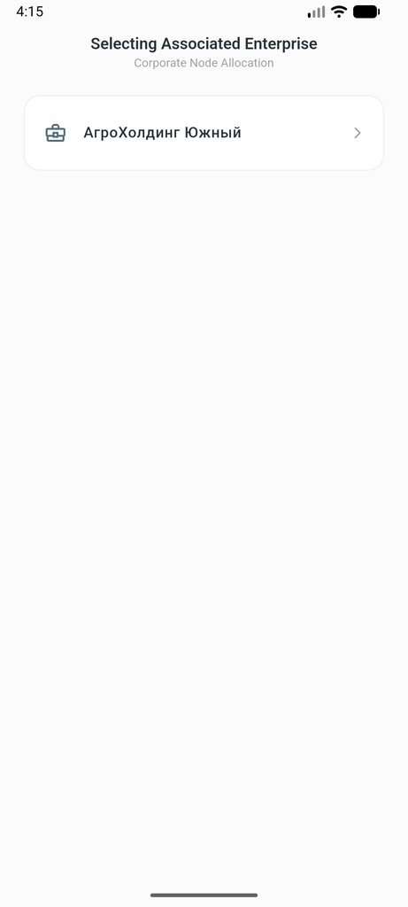

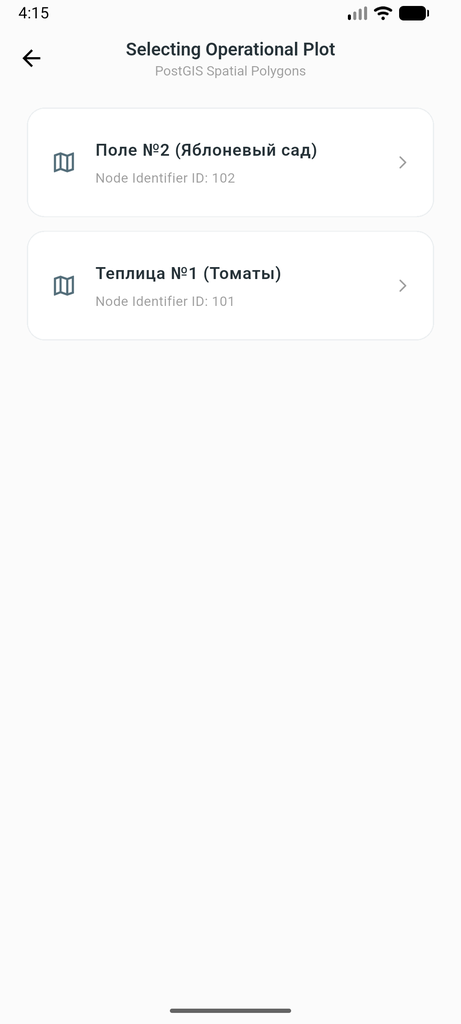

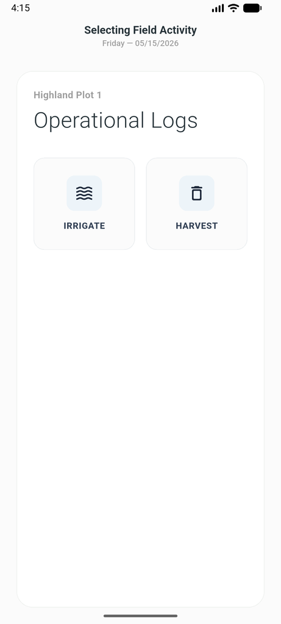

### 2.2 Продуктовые сценарии поведения (Happy Path / Edge Cases)

1. **Сценарий «Последовательный выбор трассы» (Happy Path):** Пользователь выбирает предприятие ➡️ REST API подгружает только его геозоны (поля) ➡️ Рабочий выбирает поле ➡️ Интерфейс отображает строго пересечение активностей поля и его личной квалификации.
2. **Сценарий «Офлайн-выживание в теплицах» (Offline Path):** При отсутствии сети на Шаге 3, 4 или 5 приложение извлекает закэшированные списки из локальной СУБД смартфона (SQLite/Hive), позволяя рабочему дойти до финального пульта смены без сотовой связи.

## 3 Экран «Пульт управления активной сменой» (Трекинг и Рапорты)

Главный рабочий экран («Тачпад»), отвечающий за генерацию выработки (денег рабочего) и запись голосового отчета.

### 3.1 Визуальные элементы и элементы управления (UI Elements)

- **Двухпанельный селектор (TabBar):** Вкладки «VOICE STREAM» (для записи рапорта) и «MANUAL LOG» (для спецификации данных смены).
- **Концентратор состояния сессии (Круговой таймер):** Большой белый контейнер-круг, отображающий хронометраж `recordSeconds` и текущий статус передачи (`Ready for Input` / `Transmitting WAV to S3`). Border меняет цвет (зеленый/оранжевый/красный) в зависимости от стейта.
- **Центральный триггер действия:** Круглая кнопка микрофона для удержания/нажатия при записи рапорта.
- **Информационная панель спецификации:** Карточка процесса на вкладке Manual Log, отображающая текстовый UUID сессии, имя компании, поля и текущий статус узла (`ACTIVE TRACKING`).

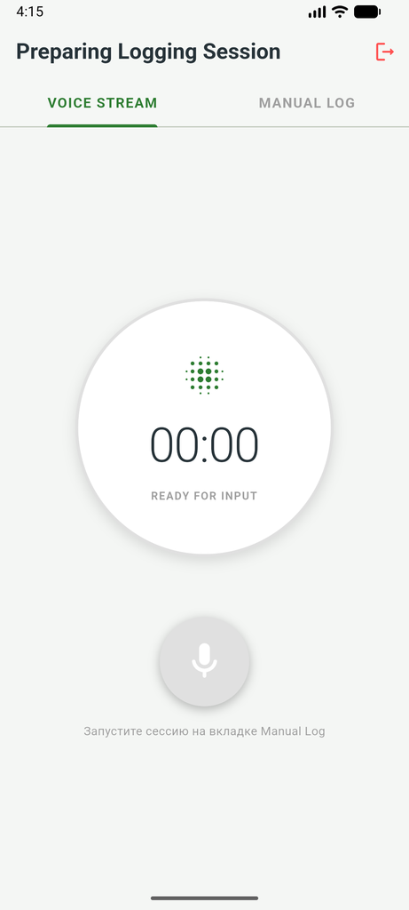

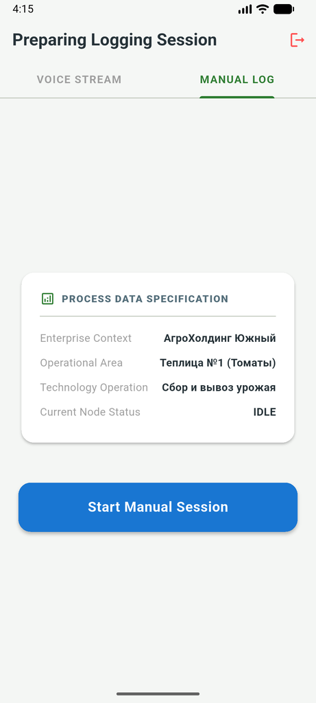

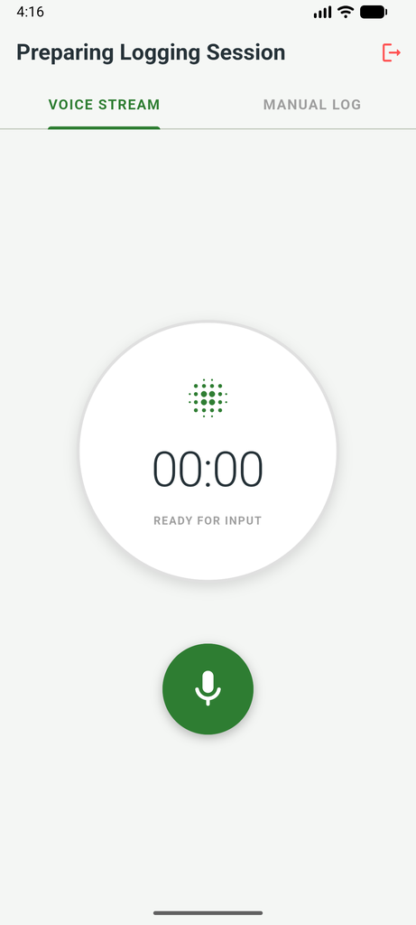

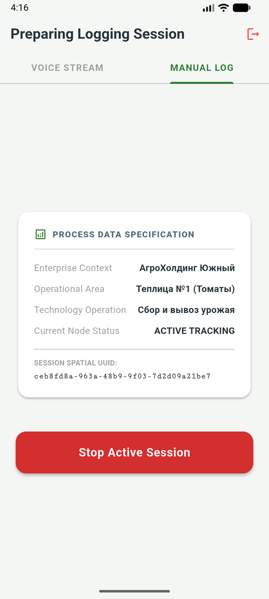

### 3.2 Продуктовые сценарии поведения (Happy Path / Edge Cases)

1. **Сценарий «Автоматическое восстановление трассы» (Happy Path):** Если рабочий смахнул или аварийно закрыл приложение, при повторном старте метод `getActiveSession()` находит в Postgres незакрытый `session_id`. Приложение мгновенно перескакивает экраны выбора и открывает пульт смены с восстановленными таймерами.
2. **Сценарий «Сдача сырья и ИИ-рапорт»:** Рабочий зажимает микрофон ➡️ Записывается бинарный `.wav` в локальный кэш телефона ➡️ При отправке файл улетает в MinIO S3. ИИ-воркер парсит запись, сверяет с ГЕО-треком и ClickHouse фиксирует заработанные за смену деньги.
3. **Сценарий «Нарушение периметра (Геофенсинг)» (Edge Case):** Если фоновый сбор координат фиксирует выход за рамки PostGIS полигона теплицы, бэкенд маркирует сессию флагом `SUSPICIOUS`, приостанавливая автоматический расчет выработки.

## 4 Сценарий «Бесшовное обновление сессии» (Token Refresh Lifecycle)

Скрытый от глаз пользователя сквозной сценарий, отвечающий за непрерывность рабочего процесса.

### 4.1 Визуальные элементы и элементы управления (UI Elements)

- *Сценарий полностью автономен и не содержит явных элементов UI.* При его активации на экране отображается Shimmer-эффект ожидания или системный лоадер `CircularProgressIndicator` поверх текущего окна.

### 4.2 Сценарий поведения системы (Happy Path)

1. Пользователь нажимает «Старт смены» на Шаге 6.
2. Входящий REST-запрос `POST /api/v1/sessions/start` падает на прокси Nginx холдинга со статусом `401 Unauthorized` (так как 15-минутный Access JWT истек).
3. Интерцептор `Dio` во Flutter перехватывает ошибку `401`, блокирует основной поток UI и отправляет фоновый gRPC-вызов `/auth.AuthService/RefreshToken` с UUID-токеном.
4. Сервер за 24 мс обновляет сессию в Redis, возвращает новые ключи во Flutter.
5. Интерцептор подставляет новый токен в упавший запрос и повторно отправляет его в Nginx. Запрос проходит со статусом `201 Created`. Для рабочего экран не моргает, сессия запущена успешно.

## 5 Экран «Регистрация нового сотрудника»

Экран отвечает за первичный скоринг наемного рабочего в государственном реестре перед созданием корпоративной учетной записи.

### 5.1 Визуальные элементы и элементы управления (UI Elements)

- **Поля ввода персональных данных:** Текстовые инпуты «ФИО», «ИНН», «СНИЛС», «Email» и «Пароль».
- **Управляющий триггер:** Кнопка «REGISTER ACCOUNT». Инициализирует бинарный gRPC-вызов `RegisterRequest` на бэкенд (порт :8080).

### 5.2 Продуктовые сценарии поведения

1. **Сценарий «Успешный скоринг и создание карточки» (Happy Path):** Рабочий вводит данные. Бэкенд через SOAP-конверт проверяет ИНН/Email в Гос-СУБД. При ответе `SUCCESS` (Сценарий twin.1) данные записываются в локальную Postgres холдинга. Экран Flutter выдает зеленый SnackBar: *«Регистрация успешна!»* и переключает стейт на `case "LOGIN"`.
2. **Сценарий «Отказ: Гражданин не найден» (Edge Case - Сценарий twin.3):** Если Гос-СУБД возвращает `USER_NOT_FOUND`, регистрация блокируется. Интерфейс выдает ошибку: *«registration rejected: identity not found in governmental registry»*.

## 6 Экран «История выработок и KPI» (Экран баланса оператора)

Экран отвечает за прозрачность начисления денежных средств («деньги рабочего») на основе архивных логов из DWH.

### 6.1 Визуальные элементы и элементы управления (UI Elements)

- **Информационный виджет баланса (Header Card):** Крупный блок, отображающий метрику `earned_amount` — суммарно заработанные деньги за текущий расчетный период.
- **Лента исторических сессий (ListView):** Список закрытых смен со статусами. Каждая карточка содержит дату, UUID смены (`session_id`), время чистой работы внутри PostGIS-полигона и иконку статуса (`CLOSED` — зеленая галочка, `REJECTED` / `SUSPICIOUS` — оранжевый маркер аудита).

### 6.2 Продуктовые сценарии поведения

1. **Сценарий «Просмотр успешной выработки» (Happy Path):** Рабочий открывает вкладку. Приложение делает REST-запрос. Карточки в статусе `CLOSED` показывают полную сумму выплаты, рассчитанную ИИ и геофенсингом.
2. **Сценарий «Апелляция по замороженной смене» (Edge Case):** Если смена имеет статус `REJECTED` (например, из-за обрыва связи `TELEMETRY_GAP_LIMIT`), карточка отображает предупреждение: *«На удержании — требуется аудит агронома»*. Кнопка изменения данных заблокирована по правилу закрытия трассы, но доступна кнопка «Связаться с диспетчером».

## 7 Системные уведомления и Shimmer-эффекты (UI Feedback matrix)

Раздел регламентирует визуальный отклик интерфейса при длительных асинхронных операциях и межсервисных сбоях.

### 7.1 Блокировка интерфейса (shimmer Loading)

- При переходах между уровнями каскада (Шаги 3, 4, 5) во время выполнения REST-запросов к Nginx, вместо белого экрана должна отрисовываться скелетная анимация (`Shimmer Effect`) повторяющая контуры карточек предприятий/полей.
- На экранах авторизации и регистрации на время сквозного gRPC/SOAP скоринга кнопка действия переводится в стейт `disabled`, а внутри неё рендерится `CircularProgressIndicator` корпоративного зеленого цвета (`#2E7D32`).

### 7.2 Глобальная обработка разрывов сессии

- Если интерцептор `Dio` получает жесткий отказ от gRPC-метода `RefreshToken` (например, сессия принудительно стерта из Redis на сервере), приложение обязано прервать любой текущий User Journey, очистить локальный кэш токенов и бесшовно переключить `_currentStep` на экран `LOGIN`, выдав всплывающее предупреждение: *«Сессия устарела. Пожалуйста, авторизуйтесь заново»*.

## 8 Матрица UI-валидации форм ввода (Front-End Constraints)

Жесткие ограничения на стороне клиента для минимизации паразитной нагрузки на gRPC-контур авторизации.

| Элемент UI / Поле | Правило валидации на фронтенде | Поведение при нарушении |
| --- | --- | --- |
| **Email Input** | Соответствие регулярному выражению `^[a-zA-Z0-9._%+-]+@[a-zA-Z0-9.-]+\.[a-zA-Z]{2,}$` | Поле подсвечивается красным, кнопка отправки блокируется. Текст: *«Некорректный формат корпоративной почты»*. |
| **Password Input** | Длина строки `Length >= 8`. Запрет на отправку пустой строки. | Блокировка вызова метода `_handleLogin`. Текст под инпутом: *«Пароль не может быть короче 8 символов»*. |
| **ИНН Input (Регистрация)** | Строго цифровой ввод, длина ровно 12 символов. | Маска поля блокирует ввод букв и запрещает клик по кнопке `REGISTER ACCOUNT`. |
| **СНИЛС Input (Регистрация)** | Строго цифровой ввод, длина ровно 11 символов. | Валидация длины до отправки gRPC-запроса на бэкенд. |

## 9 UI/UX спецификация

1. Экран входа (с обработкой гос-блокировок).
2. Экран каскада справочников (с логикой офлайн-выживания).
3. Пульт управления сменой (с таймерами, кнопкой микрофона и UUID).
4. Экран регистрации (с передачей ИНН/СНИЛС в SOAP).
5. Экран выработки оператора (с деньгами и статусами смен из DWH).
6. Скрытый сценарий рефреша токенов (работа интерцептора).
7. Визуальный отклик и Shimmer-эффекты ( feedback-интерфейса).
8. Фронтенд-валидацию полей (маски ИНН/Email).

## 10 Доработки по UI/UX текущего приложения Flutter

1. Критическая уязвимость: Задержка при входе (Холодный старт)
- Проблема: Сейчас при нажатии кнопки «AUTHORIZE ENTRANCE» интерфейс замирает на 1-2 секунды, пока последовательно идут gRPC Login и REST getActiveSession. Пользователь может подумать, что приложение зависло, и начать судорожно кликать по кнопке повторно.
- UX-решение: На время выполнения метода _handleLogin необходимо блокировать кнопку ввода и выводить стандартный CircularProgressIndicator поверх карточки, чтобы визуально показать процесс сетевой проверки.
2. Защита от «дурака» на Экране Справочников (Каскад)
- Проблема: На шаге COMPANY или FIELD рабочий видит список карточек. Если в этот момент у него пропадет сеть (агро-зона), клик по карточке приведет к бесконечному ожиданию ответа от REST API, если не сработал локальный кэш.
- UX-решение: Добавить визуальный индикатор «Офлайн-режим» (маленькая иконка перечеркнутого Wi-Fi в AppBar), если данные подгрузились из локального кэша SQLite/Hive. Это даст рабочему понять, что система контролирует ситуацию и его данные не пропадут.
3. Информативность пульта смены (TrackingScreen)
- Проблема: Сейчас на вкладке «Manual Log» UUID сессии (session_id) выводится в виде Courier-текста. Для простого рабочего длинный хэш вроде 92fb1120-194a… выглядит как системный сбой.
- UX-решение: Спрятать сырой UUID под красивую плашку с кнопкой «Скопировать номер смены», а вместо него крупно выводить статус: «Трэкинг активен. Ваше время и выработка учитываются», чтобы рабочий визуально видел, за что ему капают деньги.